# DWEI5_Aula03_Flask-ViewsRotas

Instituto Federal de São Paulo (IFSP)  
[Campus Bragança Paulista/SP](https://bra.ifsp.edu.br)  
**Análise e Desenvolvimento de Sistemas (ADS)**  
**5o. módulo**  
**Profa. Ana Paula Müller Giancoli**  
paulagiancoli@ifsp.edu.br

## AULA 03 - CONCEITOS DE VIEWS e ROTAS

### Agenda

- Apresentação VIEWS e ROTAS
- Tipos de roteamento
  - Roteamento não explícito
  - Roteamento explícito
  - Regras de URLs
  - Construção de URLs
- Métodos HTTP
- Perguntas

### 1.1. Apresentação VIEWS e ROTAS

- As **views** são funções, ou classes que respondem por uma determinada **URL**.
- A função da **view** é capturar os parâmetros enviados pelo cliente por meio da **URL**, e efetuar o processamento com o objetivo de responder à solicitação, com algum tipo de conteúdo, mensagem de status, texto, template renderizado json etc.
- Por **exemplo**:
  - **http://localhost:8000/noticias/brasil?categoria=policia&quantidade=2**
  - **O que significa ?**
    - **/noticias/**: é o endpoint mapeado pela view.
    - **/brasil/**: é o argumento passado para a view.
    - **categoria=policia&quantidade=2**: são os parâmetros (categoria e quantidade) passados para a view.
    - O Flask faz boa parte do roteamento por meio do **@app.route()**.
    - Durante o desenvolvimento da aplicação Flask, é interessante utilizar alguns parâmetros para agilizar a depuração e codificação. Exemplo:
      - Ao invés de usar simplesmente **app.run()**. Utilize:
      - **app.run(debug=True, use_reloader=True)**: repectivamente, o atributo debug auxilia na identificação do erro, caso ocorra. E o atributo use-reloader, facilita reiniciar o servidor flask, sempre que ocorrer alguma alteração nos arquivos. Ao lançar em produção, altere para False.

### 2. Tipos de roteamento

### 2.1. Roteamento não explícito

- A vantagem de utilizar **.route()** para rotear é que o Flask usará o nome da função automaticamente como **endpoint**.
- Exemplo: Neste caso, o endpoint é o lista_de_noticias.

```
from flask import Flask, render_template, request

app = Flask(__name__)

@app.route("/noticias/<pais>")
def lista_de_noticias(pais):
    cat = request.args.get("categoria")
    qtd = request.args.get("quantidade")
    noticias = BD.query(pais=pais, categoria=cat).limit(qtd)
    return render_template("lista_de_noticias", noticias=noticias), 200

app.run(debug=True, use_reloader=True)
```

### 2.2. Roteamento explícito

- Muito útil quando necessita automatizar ou centralizar o mapeamento de urls em um único local do projeto. É a maneira utilizada pelos Blueprints.
- Desvantagens: há necessidade de informar explicitamente cada endpoint e a função da view a ser mapeada.
- Exemplo:

```
app.add_url_rule("/noticias/<pais>"),
                endpoint = "lista_de_noticias",
                view_func = lista_de_noticias)
```

### 2.3. Regras de URLs

- De acordo com [Rocha, Bruno](http://pythonclub.com.br/what-the-flask-pt-1-introducao-ao-desenvolvimento-web-com-python.html), as urls são recebidas no formato texto.
  - Por exemplo: **/noticias/1**.
    - Em alguns casos queremos que o valor passado como argumento seja convertido para um tipo de dados específico, ou seja, queremos receber o 1 como um inteiro.
    - **O Flask utiliza como base a ferramenta Werkzeug que internamente utiliza o .route() e alguns conversores para as regras de URLs**.
    - Tipos de conversores: **< converter : variavel >**
      - **string**: **@app.route("/user/< username >")**
      - **int**: **@app.route("/user/< int:id >")**
      - **float**: **@app.route("/user/< float:dollar >")**
      - **path**: **@app.route("/user/< path:subpath >")**
    - Os **conversores** padrões são:
      - **/noticias/< categoria >**, recebe o parâmetro "categoria" no formato unicode, exemplo "entretenimento".
      - **/noticias/< int:noticia_id >**, recebe o parâmetro "noticia_id" no formato inteiro, exemplo: "1".
      - **/cotacao/< float:dolar >/**, recebe o parâmetro "dolar" como float, exemplo: "3.2".
      - **/imagem/< path >**, recebe o parâmetro "path" como um caminho, exemplo: "animais/marssupiais/quokka.png".
      - Também é possivel utilizar regex, passar parâmetros para validação ou até mesmo criar seus próprios conversores de url.

**Observação IMPORTANTE**:

- Se *declarar a url* **sem a barra no final** e o usuário tentar acessar, somente conseguirá se não utilizar a barra no final.
- Se *declarar a url* **com a barra no final** e o usuário tentar acessar, mesmo sem indicar a barra, o Flask adiciona automaticamente.

### 2.4. Construção de URLs

- Podemos construir URLs para uma função específica, utilizando: **url_for( )**.
- Por padrão, aceita o nome da função como 1o. argumento e qualquer outro número de argumentos seguidos de combinações palavra-chave, onde cada par refere-se a uma parte variável da regra da URL.

```
<!-- Arquivo templates/base.html -->

<a href="{{ url_for('controls.profile') }}" class="navbar-item">
 Perfil
</a>
```

### 3. Métodos HTTP

- Os aplicativos da web utilizam diversas formas de acesso por meio de URLs e métodos **HTTP**.
- Por padrão, no Flask uma rota responde apenas a solicitações **GET**.
- Porém, pode-se utilizar o argumento **METHODS** nas rotas criadas por **.route()** para lidar com diferentes métodos de acesso.
- Por exemplo:

```
from flask import request

@app.route('/login', methods=['GET', 'POST'])
def login():
    if request.method == 'POST':
        return do_the_login()
    else:
        return show_the_login_form()
```

### 3.1. Arquivos estáticos

- Para utilizar arquivos de **extensões css, js** e outros tipos estáticos, utiliza-se a criação de uma pasta nomeada **static** dentro da pasta **app**, ao lado da pasta **templates**.
- Para gerar as URLs dos arquivos estáticos, utiliza-se:
  - **url_for('static', filename='style.css')**
- E o arquivo **style.css**, deve ser inserido na pasta **static**.
- O Flask utiliza o mecanismo de Template Jinja2 para gerar os arquivos HTML.
- Para renderizar um template, utilize: **render_template('nomeTemplete.html')**. Onde que **nomeTemplete.html** deve estar dentro da pasta **templates**.
- É possível passar variáveis para os templates, veremos mais adiante.

### 4. Exemplificando

- Copie e cole a pasta do projeto da Aula02.
- Renomeie a pasta para Aula03.

### 4.1. Editando os arquivos:

```
# projeto/__init__.py

# Importando o flask
from flask import Flask

# Para renderizar o template
from flask import render_template, request

# __name__ : indica o pacote onde a aplicacao esta.
app = Flask(__name__)

# Criando a primeira rota, no caso, a raiz da aplicacao
# Quando criamos rotas seguidas uma da outra, elas acessam a
# mesma requisicao HTTP.
@app.route("/")
@app.route("/index")

# Criamos uma funcao com mesmo nome da rota para manter padrao
# e facilitar o entendimento
def index():
    return render_template("index.html")

@app.route('/listagem/')                                         <------------------- Adicionado
def listagem():
    valores = [
        {'id': 1, 'logradouro': 'Avenida das Flores'},
        {'id': 2, 'logradouro': 'Avenida das Carmelas'},
        {'id': 3, 'logradouro': 'Avenida das Crisantemos'},
        {'id': 4, 'logradouro': 'Avenida das Acácias'},
        {'id': 5, 'logradouro': 'Avenida das Pastorinhas'}
    ]
    return render_template('listagem.html', endereco=valores)    <------------------- Até aqui

# Verificamos se o arquivo app.py está sendo executado pelo terminal e,
# caso positivo, iniciamos o servidor do Flask.
if __name__ == "__main__":
    app.run()
```

### 4.2. Criando arquivos

- Crie dentro da pasta **templates** o arquivo:
  - **listagem.html**
- Inserir o código abaixo:

```
<!-- projeto/templates/listagem.html -->
{% extends "base.html" %}

{% block content %}
    <h1>Listagem dos Endereços</h1>
    <p>Exemplo de recebimento de um dicionário, no caso: endereco.</p>
    <p>Ao ser selecionado a rota <strong>@app.route('/listagem/')</strong>, o retorno do método é renderizar o template <strong>'listagem.html'</strong> passando o parâmetro <strong>endereco=valores</strong></p>
    <ul>
        {% for end in endereco %}
            <li>ID: {{end.id}} -  Logradouro: {{end.logradouro}}</li>
        {% endfor %}
    </ul>
{% endblock %}
```

### 4.3. Testando as alterações

- Reinicie o servidor Flask. Para encerrar, no terminal, tecle: **ctrl+c**.
- Acesse a pasta **app**, e execute:

```
python3 __init__.py
```

- O servidor flask será iniciado.

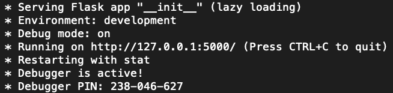

- Copie e cole no navegador: **http://127.0.0.1:5000/**
- Agora, acrescente na barra de endereço: **/listagem**. Será exibido a tela abaixo:

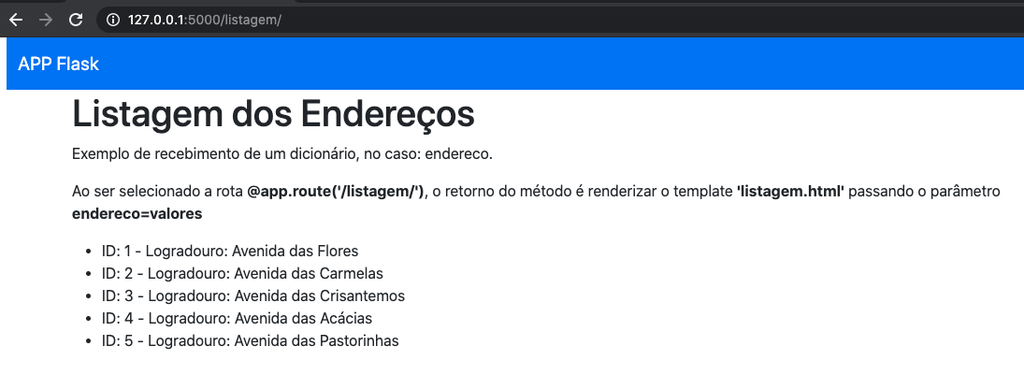

### ATENÇÃO

- **Lembre-se de encerrar o servidor ao final de cada aula**.
- **Lembre-se também, de desativar o ambiente virtual**.

### Referências

- Esta aula foi elaborada a partir do conteúdo disponibilizado em cada um dos links indicados no próprio texto.

### Perguntas

- Esclareça suas eventuais dúvidas durante as aulas.
- Ou pelo *E-mail*: paulagiancoli@ifsp.edu.br.
- Ou acesse [Github Ana Giancoli](https://anagiancoli.github.io) e solicite atendimento para o componente curricular.

*ADS - HTML5, CSS3, JS, FLASK - 5o. módulo*.  
Modelo e formato elaborado por profa. Ana Paula Müller Giancoli - BSD 2-Clause License. - Fevereiro.2021.